# Caso Práctico 06: BMW vs Volkswagen

Beatriz Cárdaba

25/11/2020

### Utilizando datos diarios de los dos series desde el año 2014, debemos analizar la relación entre BMW y Volkswagen, contestando a las siguiente preguntas:

**Estimar el modelo garch de BMW**

El modelo GARCH es un modelo autorregresivo generalizado que captura las agrupaciones de volatilidad de las rentabilidades a través de la varianza condicional.

En otras palabras, el modelo GARCH consiste en estimar un modelo ARMA para la volatilidad (varianza de los errores) . En este entorno, la volatilidad nos indica los riesgos de de los activos.

En este caso se va aestimar un modelo GARCH para los activos de BMW desde 2014, para ello se importan los datos de YAHOO FINANCE de BWM en la bolsa alemana. Se seleccionan los datos ajustados de cierre de cada jornada ya que el análisis será diario.

Visualizamos el Precio y la Rentabilidad de los activos de BMW:

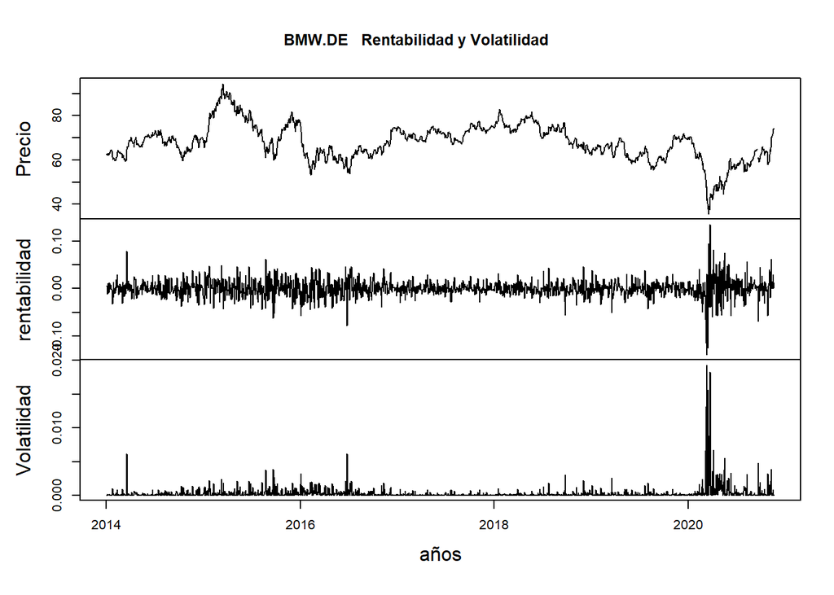

Se observa que ante una caída en el precio la rentabilidad de comprar esos activos sube, si se compra barato un activo es más probable que se revalorice e incremente su valor. Además estos cambios provocan un aumento de la volatilidad.

Se realiza es test para conocer si la media de los rendimientos es 0.

```
##
##  One Sample t-test
##
## data:  BMW_dRentCont
## t = 0.23186, df = 1743, p-value = 0.8167
## alternative hypothesis: true mean is not equal to 0
## 95 percent confidence interval:
##  -0.0007329059  0.0009294196
## sample estimates:
##    mean of x
## 9.825686e-05
```

Dado el valor del P-Value no podemos rechazar la H0 que indica que la media de los rendimietnos es 0

Calculamos la Autocorrelación de los rendimientos. Es decir como influyen los valores de los rendimientos anteriores en los rendimientos porsteriores.

Y comprobamos si son ruido blanco:

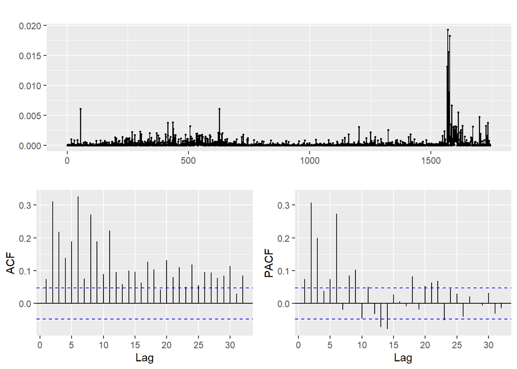

Vemos que la volatilidad no es ruido blanco, por lo que habrá que realizar un ARMA sobre la volatilidad, es lo que llamamos un modelo GARCH

Realizamos los Ljung-Box Test para diferentes grados de libertad:

```
##
##  Box-Ljung test
##
## data:  VolProxy
## X-squared = 760.2, df = 10, p-value < 2.2e-16
```

```
##
##  Box-Ljung test
##
## data:  VolProxy
## X-squared = 990.88, df = 20, p-value < 2.2e-16
```

```
##
##  Box-Ljung test
##
## data:  VolProxy
## X-squared = 1228.1, df = 40, p-value < 2.2e-16
```

Todos elloss presentan un P-Valor cercano a 0

Test de Multiplicadores de Langrage de Engle (LM), donde la hipótesis nula es de no GARCH

```
##
## Call:
## lm(formula = atsq ~ x)
##
## Residuals:
##        Min         1Q     Median         3Q        Max
## -0.0047897 -0.0002218 -0.0001055  0.0000525  0.0181126
##
## Coefficients:
##               Estimate Std. Error t value Pr(>|t|)
## (Intercept)  8.956e-05  2.561e-05   3.497 0.000483 ***
## x1          -3.657e-02  2.420e-02  -1.511 0.130883
## x2           2.368e-01  2.421e-02   9.780  < 2e-16 ***
## x3           9.311e-02  2.483e-02   3.750 0.000183 ***
## x4          -1.131e-02  2.494e-02  -0.454 0.650226
## x5           8.514e-02  2.493e-02   3.415 0.000653 ***
## x6           2.476e-01  2.502e-02   9.896  < 2e-16 ***
## x7          -2.278e-02  2.564e-02  -0.889 0.374345
## x8           1.240e-01  2.557e-02   4.850 1.35e-06 ***
## x9           7.580e-02  2.573e-02   2.946 0.003259 **
## x10         -4.134e-02  2.583e-02  -1.600 0.109760
## x11          7.648e-02  2.584e-02   2.960 0.003121 **
## x12         -4.514e-02  2.585e-02  -1.747 0.080903 .
## x13         -8.418e-02  2.572e-02  -3.273 0.001084 **
## x14         -8.889e-02  2.582e-02  -3.443 0.000590 ***
## x15          1.726e-02  2.516e-02   0.686 0.492730
## x16         -1.194e-02  2.512e-02  -0.475 0.634572
## x17         -6.102e-03  2.512e-02  -0.243 0.808075
## x18          6.852e-02  2.508e-02   2.732 0.006352 **
## x19         -1.580e-02  2.442e-02  -0.647 0.517824
## x20          5.450e-02  2.442e-02   2.232 0.025771 *
## ---
## Signif. codes:  0 '***' 0.001 '**' 0.01 '*' 0.05 '.' 0.1 ' ' 1
##
## Residual standard error: 0.0008746 on 1703 degrees of freedom
## Multiple R-squared:  0.2416, Adjusted R-squared:  0.2326
## F-statistic: 27.12 on 20 and 1703 DF,  p-value: < 2.2e-16
```

## Modelos ARCH y GARCH:

**Modelos ARCH** Los modelos de ARCH se emplean comúnmente en el modelado de series de tiempo financieras que presentan agrupaciones de volatilidad variables en el tiempo, es decir, períodos de oscilaciones entremezclados con períodos de relativa calma. A veces se considera que los modelos de tipo ARCH pertenecen a la familia de modelos de volatilidad estocástica , aunque esto es estrictamente incorrecto ya que en el tiempo t la volatilidad es completamente predeterminada (determinista) dados los valores anteriores.

**Modelo ARCH(q)**

Cuando la varianza condicional del modelo ARCH depende de m´as de un retardo, es decir, también se tienen en cuenta los anteriores a este para estimar dicha varianza, se extiende el modelo tomando el nombre de ARCH(q), donde q es el n´umero de retardos que se tienen en cuenta.

Estimamos un modelo ARCH(1)

```
##
## Title:
##  GARCH Modelling
##
## Call:
##  garchFit(formula = ~1 + garch(1, 0), data = BMW_dRentCont, trace = F)
##
## Mean and Variance Equation:
##  data ~ 1 + garch(1, 0)
## <environment: 0x0000000020b08af8>
##  [data = BMW_dRentCont]
##
## Conditional Distribution:
##  norm
##
## Coefficient(s):
##         mu       omega      alpha1
## 0.00016959  0.00022968  0.31974460
##
## Std. Errors:
##  based on Hessian
##
## Error Analysis:
##         Estimate  Std. Error  t value Pr(>|t|)
## mu     1.696e-04   3.908e-04    0.434    0.664
## omega  2.297e-04   1.038e-05   22.119  < 2e-16 ***
## alpha1 3.197e-01   4.573e-02    6.992  2.7e-12 ***
## ---
## Signif. codes:  0 '***' 0.001 '**' 0.01 '*' 0.05 '.' 0.1 ' ' 1
##
## Log Likelihood:
##  4615.964    normalized:  2.646768
##
## Description:
##  Mon Nov 30 15:56:03 2020 by user: Beatriz
##
##
## Standardised Residuals Tests:
##                                 Statistic p-Value
##  Jarque-Bera Test   R    Chi^2  3785.134  0
##  Shapiro-Wilk Test  R    W      0.9373688 0
##  Ljung-Box Test     R    Q(10)  23.46472  0.009155296
##  Ljung-Box Test     R    Q(15)  31.67059  0.007136373
##  Ljung-Box Test     R    Q(20)  37.59545  0.009918778
##  Ljung-Box Test     R^2  Q(10)  317.2676  0
##  Ljung-Box Test     R^2  Q(15)  379.4087  0
##  Ljung-Box Test     R^2  Q(20)  471.0519  0
##  LM Arch Test       R    TR^2   231.347   0
##
## Information Criterion Statistics:
##       AIC       BIC       SIC      HQIC
## -5.290097 -5.280698 -5.290103 -5.286622
```

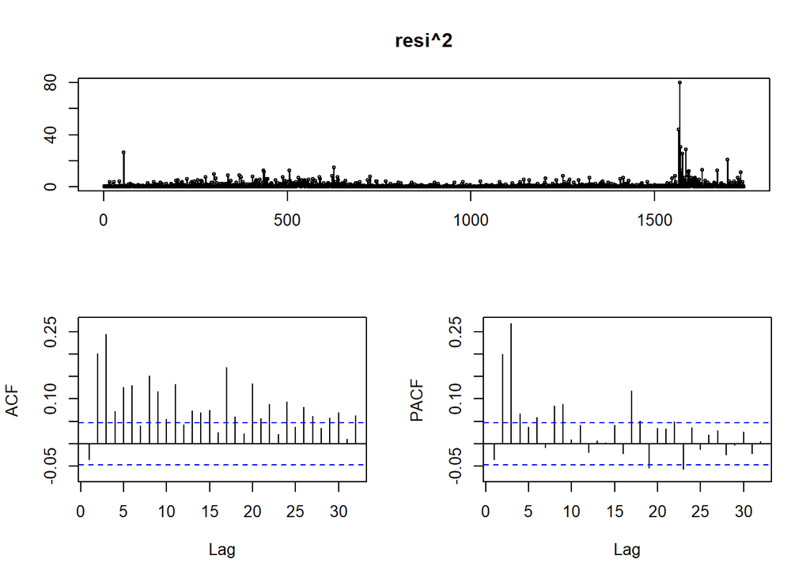

**Modelos GARCH**

La varianza condicional no solo depende de los cuadrados de las perturbaciones, como en el modelo ARCH de Engle, sino que adem´as tambi´en depende de las varianzas condicionales de periodos anteriores, es decir, de σ^2t pasados.

```
##
## Title:
##  GARCH Modelling
##
## Call:
##  garchFit(formula = ~1 + garch(1, 1), data = BMW_dRentCont, trace = F)
##
## Mean and Variance Equation:
##  data ~ 1 + garch(1, 1)
## <environment: 0x000000001c8499f0>
##  [data = BMW_dRentCont]
##
## Conditional Distribution:
##  norm
##
## Coefficient(s):
##         mu       omega      alpha1       beta1
## 3.0838e-04  2.5061e-06  4.9992e-02  9.4262e-01
##
## Std. Errors:
##  based on Hessian
##
## Error Analysis:
##         Estimate  Std. Error  t value Pr(>|t|)
## mu     3.084e-04   3.362e-04    0.917   0.3590
## omega  2.506e-06   9.819e-07    2.552   0.0107 *
## alpha1 4.999e-02   8.027e-03    6.228 4.72e-10 ***
## beta1  9.426e-01   9.581e-03   98.389  < 2e-16 ***
## ---
## Signif. codes:  0 '***' 0.001 '**' 0.01 '*' 0.05 '.' 0.1 ' ' 1
##
## Log Likelihood:
##  4787.271    normalized:  2.744995
##
## Description:
##  Mon Nov 30 15:56:03 2020 by user: Beatriz
##
##
## Standardised Residuals Tests:
##                                 Statistic p-Value
##  Jarque-Bera Test   R    Chi^2  752.0988  0
##  Shapiro-Wilk Test  R    W      0.9721381 0
##  Ljung-Box Test     R    Q(10)  22.15101  0.01435353
##  Ljung-Box Test     R    Q(15)  26.4987   0.03309633
##  Ljung-Box Test     R    Q(20)  32.62649  0.0370634
##  Ljung-Box Test     R^2  Q(10)  21.44359  0.01820418
##  Ljung-Box Test     R^2  Q(15)  22.83815  0.08763727
##  Ljung-Box Test     R^2  Q(20)  26.295    0.1562885
##  LM Arch Test       R    TR^2   21.90507  0.03859765
##
## Information Criterion Statistics:
##       AIC       BIC       SIC      HQIC
## -5.485402 -5.472870 -5.485413 -5.480769
```

Los derivados se negocia el precio futuro , la volatilidad del activo subyacente determina el valor de los derivados.

# Plantear un modelo VAR mensual entre los activos de BMW y de VOLKSWAGEN.

Se extraen los activos de estas compaías a traves de la librería Quantmod en Yahoo Finance.

Loas activos son datos diarios desde el 2014-01-01" hasta el “2020-11-25”, sin embargo, en este casp se calculan las rentabilidades mensuales. Para ello se genera un vector con los datos mensuales de ambas compañías

### Modelos VAR:

Utilizamos un modelo del tipo vector autoregresivo (VAR) cuando queremos caracterizar las interacciones simultáneas entre un grupo de variable. Un VAR es un modelo de ecuaciones simultáneas formado por un sistema de ecuaciones de forma reducida sin restringir. Que sean ecuaciones de forma reducida quiere decir que los valores contemporáneos de las variables del modelo no aparecen como variables explicativas en ninguna de las ecuaciones. Por el contrario, el conjunto de variables explicativas de cada ecuación está constituido por un bloque de retardos de cada una de las variables del modelo. Que sean ecuaciones no restringidas significa que aparece en cada una de ellas el mismo grupo de variables explicativas.

Seleccionamos el mejor modelo var automáticamente.

```
## $selection
## AIC(n)  HQ(n)  SC(n) FPE(n)
##      2      1      1      2
##
## $criteria
##                    1             2             3             4             5
## AIC(n) -1.048577e+01 -1.051103e+01 -10.427061787 -1.032392e+01 -1.030080e+01
## HQ(n)  -1.041075e+01 -1.038599e+01 -10.252006622 -1.009885e+01 -1.002571e+01
## SC(n)  -1.029751e+01 -1.019727e+01  -9.987795593 -9.759146e+00 -9.610524e+00
## FPE(n)  2.793363e-05  2.724603e-05   0.000029655  3.292114e-05  3.376201e-05
##                    6             7             8             9            10
## AIC(n) -1.031786e+01 -1.026300e+01 -1.024309e+01 -1.017443e+01 -1.015272e+01
## HQ(n)  -9.992755e+00 -9.887886e+00 -9.817956e+00 -9.699280e+00 -9.627555e+00
## SC(n)  -9.502077e+00 -9.321720e+00 -9.176301e+00 -8.982136e+00 -8.834922e+00
## FPE(n)  3.329243e-05  3.531740e-05  3.622789e-05  3.907934e-05  4.029418e-05
```

```
##
## VAR Estimation Results:
## =========================
## Endogenous variables: BMW, VOW
## Deterministic variables: const
## Sample size: 82
## Log Likelihood: 209.606
## Roots of the characteristic polynomial:
## 0.2238 0.2238
## Call:
## VAR(y = vY)
##
##
## Estimation results for equation BMW:
## ====================================
## BMW = BMW.l1 + VOW.l1 + const
##
##         Estimate Std. Error t value Pr(>|t|)
## BMW.l1  0.179122   0.172278   1.040   0.3016
## VOW.l1 -0.297549   0.153666  -1.936   0.0564 .
## const   0.006158   0.008988   0.685   0.4953
## ---
## Signif. codes:  0 '***' 0.001 '**' 0.01 '*' 0.05 '.' 0.1 ' ' 1
##
##
## Residual standard error: 0.08136 on 79 degrees of freedom
## Multiple R-Squared: 0.04819, Adjusted R-squared: 0.0241
## F-statistic:     2 on 2 and 79 DF,  p-value: 0.1421
##
##
## Estimation results for equation VOW:
## ====================================
## VOW = BMW.l1 + VOW.l1 + const
##
##         Estimate Std. Error t value Pr(>|t|)
## BMW.l1  0.376485   0.184105   2.045   0.0442 *
## VOW.l1 -0.345878   0.164216  -2.106   0.0384 *
## const   0.004578   0.009606   0.477   0.6349
## ---
## Signif. codes:  0 '***' 0.001 '**' 0.01 '*' 0.05 '.' 0.1 ' ' 1
##
##
## Residual standard error: 0.08694 on 79 degrees of freedom
## Multiple R-Squared: 0.0598,  Adjusted R-squared: 0.03599
## F-statistic: 2.512 on 2 and 79 DF,  p-value: 0.08755
##
##
##
## Covariance matrix of residuals:
##          BMW      VOW
## BMW 0.006619 0.005272
## VOW 0.005272 0.007559
##
## Correlation matrix of residuals:
##        BMW    VOW
## BMW 1.0000 0.7453
## VOW 0.7453 1.0000
```

```
##
## VAR Estimation Results:
## =========================
## Endogenous variables: BMW, VOW
## Deterministic variables: none
## Sample size: 82
## Log Likelihood: 209.362
## Roots of the characteristic polynomial:
## 0.2235 0.2235
## Call:
## VAR(y = vY, type = "none")
##
##
## Estimation results for equation BMW:
## ====================================
## BMW = BMW.l1 + VOW.l1
##
##        Estimate Std. Error t value Pr(>|t|)
## BMW.l1   0.1823     0.1716   1.062   0.2914
## VOW.l1  -0.2987     0.1531  -1.950   0.0547 .
## ---
## Signif. codes:  0 '***' 0.001 '**' 0.01 '*' 0.05 '.' 0.1 ' ' 1
##
##
## Residual standard error: 0.08109 on 80 degrees of freedom
## Multiple R-Squared: 0.04803, Adjusted R-squared: 0.02423
## F-statistic: 2.018 on 2 and 80 DF,  p-value: 0.1396
##
##
## Estimation results for equation VOW:
## ====================================
## VOW = BMW.l1 + VOW.l1
##
##        Estimate Std. Error t value Pr(>|t|)
## BMW.l1   0.3789     0.1831   2.069   0.0418 *
## VOW.l1  -0.3467     0.1634  -2.122   0.0370 *
## ---
## Signif. codes:  0 '***' 0.001 '**' 0.01 '*' 0.05 '.' 0.1 ' ' 1
##
##
## Residual standard error: 0.08652 on 80 degrees of freedom
## Multiple R-Squared: 0.06012, Adjusted R-squared: 0.03663
## F-statistic: 2.559 on 2 and 80 DF,  p-value: 0.08372
##
##
##
## Covariance matrix of residuals:
##          BMW      VOW
## BMW 0.006536 0.005206
## VOW 0.005206 0.007465
##
## Correlation matrix of residuals:
##        BMW    VOW
## BMW 1.0000 0.7453
## VOW 0.7453 1.0000
```

Se calcula la causalidad de Granger para saber si las rentabilidades BMW afectan aa las rentabilidades Volskwagen y viceversa, es decir, si hay un efecto bidireccional:

```
## $Granger
##
##  Granger causality H0: BMW do not Granger-cause VOW
##
## data:  VAR object model.var1
## F-Test = 4.279, df1 = 1, df2 = 160, p-value = 0.0402
##
##
## $Instant
##
##  H0: No instantaneous causality between: BMW and VOW
##
## data:  VAR object model.var1
## Chi-squared = 29.326, df = 1, p-value = 6.117e-08
```

Esto quiere decir que existe una relación contemporánea.

Vista esta caulaidad a continuación, se estudia como va a afectar en Volskwagen un cambio porducido en BMW, y viceversa.

```
##
## Impulse response coefficients
## $BMW
##                 BMW           VOW
##  [1,]  8.108738e-02  6.455855e-02
##  [2,] -4.498855e-03  8.337073e-03
##  [3,] -3.310170e-03 -4.594938e-03
##  [4,]  7.688943e-04  3.390421e-04
##  [5,]  3.891273e-05  1.737481e-04
##  [6,] -4.479880e-05 -4.549788e-05
##  [7,]  5.421656e-06 -1.197584e-06
##  [8,]  1.346074e-06  2.469218e-06
##  [9,] -4.920772e-07 -3.461375e-07
## [10,]  1.367159e-08 -6.641539e-08
## [11,]  2.232847e-08  2.820632e-08
```

[output cut: 74 more lines]

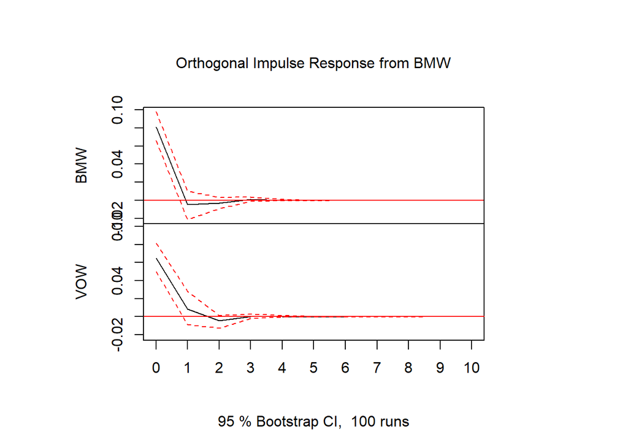

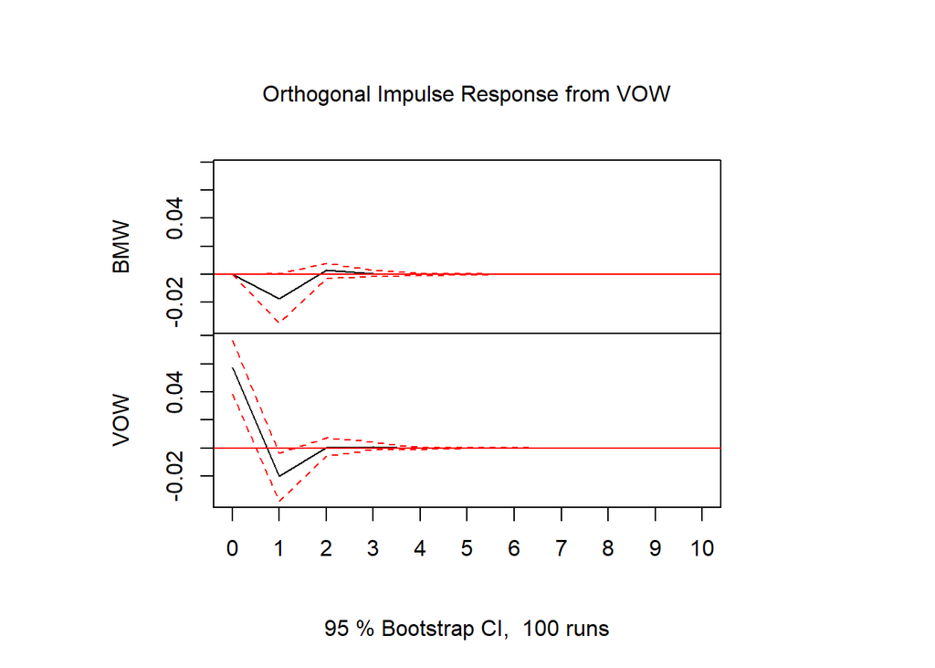

Con estados datos es posible realizar una predicción para los valores futuroos posibles que van a tomar ambas empresas

```
## $BMW
##               fcst      lower     upper        CI
## [1,] -2.008621e-02 -0.1790145 0.1388421 0.1589283
## [2,] -1.201789e-02 -0.1747232 0.1506874 0.1627053
## [3,]  2.978967e-03 -0.1599500 0.1659079 0.1629290
## [4,]  1.104633e-04 -0.1628273 0.1630482 0.1629378
## [5,] -1.669411e-04 -0.1631052 0.1627713 0.1629383
## [6,]  2.192884e-05 -0.1629164 0.1629602 0.1629383
## [7,]  4.732460e-06 -0.1629336 0.1629430 0.1629383
## [8,] -1.873241e-06 -0.1629402 0.1629364 0.1629383
##
## $VOW
##               fcst      lower     upper        CI
## [1,]  2.797791e-02 -0.1416024 0.1975582 0.1695803
## [2,] -1.730989e-02 -0.1921148 0.1574950 0.1748049
## [3,]  1.448495e-03 -0.1735901 0.1764870 0.1750386
## [4,]  6.263807e-04 -0.1744229 0.1756757 0.1750493
## [5,] -1.753226e-04 -0.1752253 0.1748747 0.1750500
## [6,] -2.460008e-06 -0.1750525 0.1750475 0.1750500
## [7,]  9.160687e-06 -0.1750408 0.1750592 0.1750500
## [8,] -1.383191e-06 -0.1750514 0.1750486 0.1750500
```